# Part I - Student Performance Data Exploration

## By Benjamin Ogbonna

### Last Updated August 23, 2022

## Introduction

> This is a dataset about students' scores/performance in a test.  
> The aim of this exploration/analysis is to identify if there are certain factors that contribute or affect students' success in a given test/exam.

## Preliminary Wrangling

> To understand the factors contributing to the success or failures of students

```python
# import all packages and set plots to be embedded inline
import numpy as np
import pandas as pd
import matplotlib.pyplot as plt
import seaborn as sb

plt.style.use('fivethirtyeight')
%matplotlib inline
```

```python
# get data

student_data = pd.read_csv('students_performance_data.csv')
```

```python
# view some samples of data

student_data.head(10)
```

|  | gender | race/ethnicity | parental level of education | lunch | test preparation course | math score | reading score | writing score |
| --- | --- | --- | --- | --- | --- | --- | --- | --- |
| 0 | female | group B | bachelor's degree | standard | none | 72 | 72 | 74 |
| 1 | female | group C | some college | standard | completed | 69 | 90 | 88 |
| 2 | female | group B | master's degree | standard | none | 90 | 95 | 93 |
| 3 | male | group A | associate's degree | free/reduced | none | 47 | 57 | 44 |
| 4 | male | group C | some college | standard | none | 76 | 78 | 75 |
| 5 | female | group B | associate's degree | standard | none | 71 | 83 | 78 |
| 6 | female | group B | some college | standard | completed | 88 | 95 | 92 |
| 7 | male | group B | some college | free/reduced | none | 40 | 43 | 39 |
| 8 | male | group D | high school | free/reduced | completed | 64 | 64 | 67 |
| 9 | female | group B | high school | free/reduced | none | 38 | 60 | 50 |

```python
# create a new column for total score, adding math, reading and writing score together

student_data['total_score'] = student_data['math score'] + student_data['reading score'] + student_data['writing score']

student_data.head(10)
```

|  | gender | race/ethnicity | parental level of education | lunch | test preparation course | math score | reading score | writing score | total_score |
| --- | --- | --- | --- | --- | --- | --- | --- | --- | --- |
| 0 | female | group B | bachelor's degree | standard | none | 72 | 72 | 74 | 218 |
| 1 | female | group C | some college | standard | completed | 69 | 90 | 88 | 247 |
| 2 | female | group B | master's degree | standard | none | 90 | 95 | 93 | 278 |
| 3 | male | group A | associate's degree | free/reduced | none | 47 | 57 | 44 | 148 |
| 4 | male | group C | some college | standard | none | 76 | 78 | 75 | 229 |
| 5 | female | group B | associate's degree | standard | none | 71 | 83 | 78 | 232 |
| 6 | female | group B | some college | standard | completed | 88 | 95 | 92 | 275 |
| 7 | male | group B | some college | free/reduced | none | 40 | 43 | 39 | 122 |
| 8 | male | group D | high school | free/reduced | completed | 64 | 64 | 67 | 195 |
| 9 | female | group B | high school | free/reduced | none | 38 | 60 | 50 | 148 |

```python
# Creating a another new column for grade, to grade students based on their scores (A, B, C, D or F):

# 0-59 =   F
# 60-69 =  D
# 70-79 =  C
# 80-89 =  B
# 90-100 = A

student_data['grade'] = ['F' if score < 60 else 'D' if 60<=score<70 else 'C' if 70<=score<80 else 'B' if 80<=score<90 else 'A' for score in ((student_data.total_score/300) *100)]

student_data
```

|  | gender | race/ethnicity | parental level of education | lunch | test preparation course | math score | reading score | writing score | total_score | grade |
| --- | --- | --- | --- | --- | --- | --- | --- | --- | --- | --- |
| 0 | female | group B | bachelor's degree | standard | none | 72 | 72 | 74 | 218 | C |
| 1 | female | group C | some college | standard | completed | 69 | 90 | 88 | 247 | B |
| 2 | female | group B | master's degree | standard | none | 90 | 95 | 93 | 278 | A |
| 3 | male | group A | associate's degree | free/reduced | none | 47 | 57 | 44 | 148 | F |
| 4 | male | group C | some college | standard | none | 76 | 78 | 75 | 229 | C |
| ... | ... | ... | ... | ... | ... | ... | ... | ... | ... | ... |
| 995 | female | group E | master's degree | standard | completed | 88 | 99 | 95 | 282 | A |
| 996 | male | group C | high school | free/reduced | none | 62 | 55 | 55 | 172 | F |
| 997 | female | group C | high school | free/reduced | completed | 59 | 71 | 65 | 195 | D |
| 998 | female | group D | some college | standard | completed | 68 | 78 | 77 | 223 | C |
| 999 | female | group D | some college | free/reduced | none | 77 | 86 | 86 | 249 | B |

1000 rows × 10 columns

```python
# check data info

student_data.info()
```

```
<class 'pandas.core.frame.DataFrame'>
RangeIndex: 1000 entries, 0 to 999
Data columns (total 10 columns):
 #   Column                       Non-Null Count  Dtype
---  ------                       --------------  -----
 0   gender                       1000 non-null   object
 1   race/ethnicity               1000 non-null   object
 2   parental level of education  1000 non-null   object
 3   lunch                        1000 non-null   object
 4   test preparation course      1000 non-null   object
 5   math score                   1000 non-null   int64
 6   reading score                1000 non-null   int64
 7   writing score                1000 non-null   int64
 8   total_score                  1000 non-null   int64
 9   grade                        1000 non-null   object
dtypes: int64(4), object(6)
memory usage: 78.2+ KB
```

```python
# number of features/columns of our data

for x, feature in enumerate(student_data.columns):
    print(x, feature)
```

```
0 gender
1 race/ethnicity
2 parental level of education
3 lunch
4 test preparation course
5 math score
6 reading score
7 writing score
8 total_score
9 grade
```

```python
# shape of data

student_data.shape
```

```
(1000, 10)
```

```python
# descriptive statistics for numeric variables

student_data.describe()
```

|  | math score | reading score | writing score | total_score |
| --- | --- | --- | --- | --- |
| count | 1000.00000 | 1000.000000 | 1000.000000 | 1000.000000 |
| mean | 66.08900 | 69.169000 | 68.054000 | 203.312000 |
| std | 15.16308 | 14.600192 | 15.195657 | 42.771978 |
| min | 0.00000 | 17.000000 | 10.000000 | 27.000000 |
| 25% | 57.00000 | 59.000000 | 57.750000 | 175.000000 |
| 50% | 66.00000 | 70.000000 | 69.000000 | 205.000000 |
| 75% | 77.00000 | 79.000000 | 79.000000 | 233.000000 |
| max | 100.00000 | 100.000000 | 100.000000 | 300.000000 |

### What is the structure of your dataset?

> There are 1000 tuples or rows of student performance, and 10 features:

> 0 gender

> 1 race/ethnicity

> 2 parental level of education

> 3 lunch

> 4 test preparation course

> 5 math score

> 6 reading score

> 7 writing score

> 8 total_score (I added this. Not part of the main dataset)

> 9 grade (A, B, C, D or F)

### What is/are the main feature(s) of interest in your dataset?

> I'd love to know/find out what factors contribute most to a students success or failure

### What features in the dataset do you think will help support your investigation into your feature(s) of interest?

> From a peek at at the data, I think features such as Gender, Parental level of education and test preparation course would play a huge role more than othersin my findings/analysis.

## Univariate Exploration

### In this section, I will investigate distributions of individual variables.

## What number of Females and Males took the test?

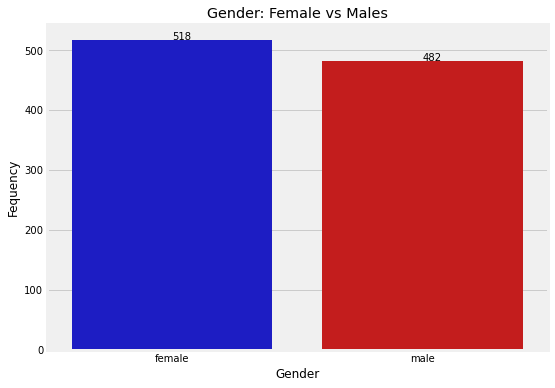

```python
plt.figure(figsize=(8, 6))
values = student_data.gender.value_counts().values
colors = ["#0101DF", "#DF0101"]
plt.title('Gender: Female vs Males')
ax = sb.countplot(x='gender', data=student_data, palette=colors)
for x, y in enumerate(ax.patches):
    height = y.get_height()
    ax.text(y.get_x()+y.get_width()/2., height + .1, values[x])
plt.xlabel('Gender')
plt.ylabel('Fequency')
plt.show()
```

From the plot, there were more females who took the test:

## what is the race/ethnicity distribution like?

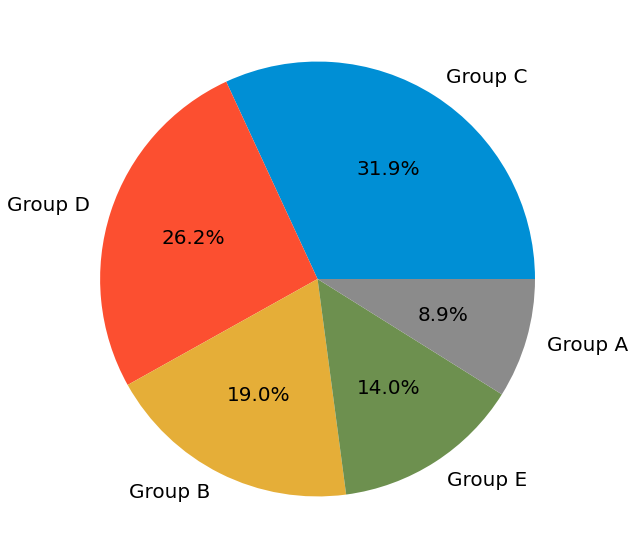

```
group C    319
group D    262
group B    190
group E    140
group A     89
Name: race/ethnicity, dtype: int64
```

```python
category_names = ['Group C', 'Group D', 'Group B', 'Group E', 'Group A']
sizes = [student_data['race/ethnicity'].value_counts()[0],
         student_data['race/ethnicity'].value_counts()[1],
         student_data['race/ethnicity'].value_counts()[2],
         student_data['race/ethnicity'].value_counts()[3],
         student_data['race/ethnicity'].value_counts()[4]]

plt.figure(figsize=(10,10))
plt.pie(sizes, labels=category_names, autopct='%1.1f%%', textprops={'fontsize': 20})
plt.show()
print(student_data['race/ethnicity'].value_counts())
```

### Looking at the pie-chat, Group C is highly represented by 31.9%, followed by Group D 26.2%, etc .

## How many students took the test preparation course?

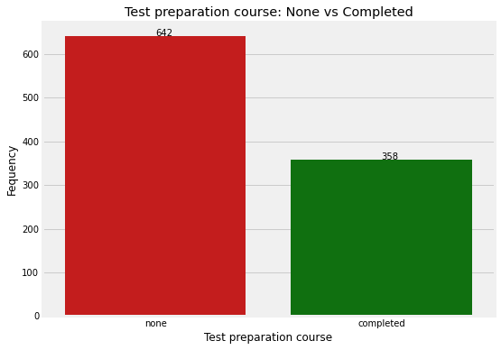

```
none         642
completed    358
Name: test preparation course, dtype: int64
```

```python
plt.figure(figsize=(8, 6))
values = student_data['test preparation course'].value_counts().values
colors = ["#DF0101", 'green']
plt.title('Test preparation course: None vs Completed')
ax = sb.countplot(x='test preparation course', data=student_data, palette=colors)
for x, y in enumerate(ax.patches):
    height = y.get_height()
    ax.text(y.get_x()+y.get_width()/2., height + .1, values[x])
plt.xlabel('Test preparation course')
plt.ylabel('Fequency')
plt.show()
print(student_data['test preparation course'].value_counts())
```

### There seems to be a big gap between those who did not take the course and those who took it. This definately should affects their total score.

## What number/percentage of parent had a certain degree (level of education)?

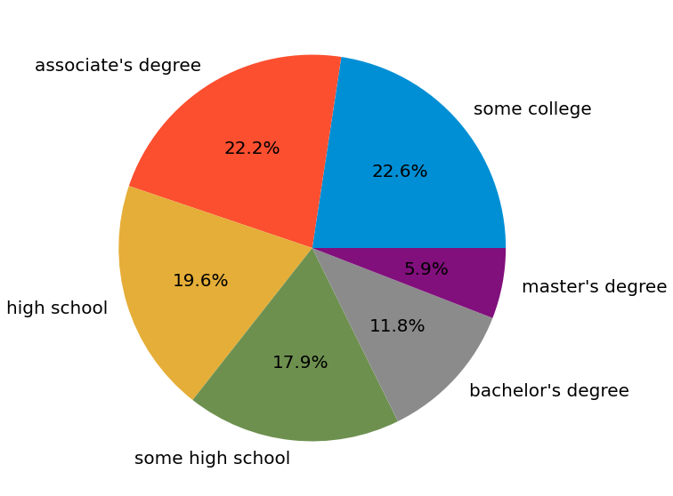

```
some college          226
associate's degree    222
high school           196
some high school      179
bachelor's degree     118
master's degree        59
Name: parental level of education, dtype: int64
```

```python
# Plotting the percentage of parent in various education level

category_names = ['some college', 'associate\'s degree', 'high school', 'some high school',
                  'bachelor\'s degree', 'master\'s degree']
sizes = [student_data['parental level of education'].value_counts()[0],
         student_data['parental level of education'].value_counts()[1],
         student_data['parental level of education'].value_counts()[2],
         student_data['parental level of education'].value_counts()[3],
         student_data['parental level of education'].value_counts()[4],
         student_data['parental level of education'].value_counts()[5]]

plt.figure(figsize=(10,10))
plt.pie(sizes, labels=category_names, autopct='%1.1f%%', textprops={'fontsize': 20})
plt.show()
print(student_data['parental level of education'].value_counts())
```

## How many students had Standard or free/reduced lunch?

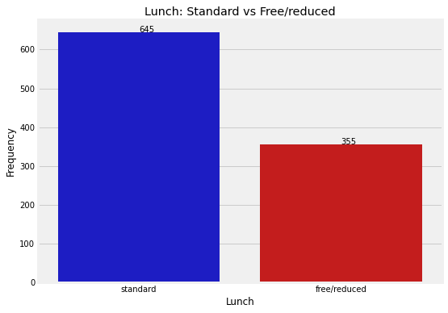

```
standard        645
free/reduced    355
Name: lunch, dtype: int64
```

```python
plt.figure(figsize=(8, 6))
values = student_data['lunch'].value_counts().values
colors = ['#0101DF', "#DF0101"]
plt.title('Lunch: Standard vs Free/reduced')
ax = sb.countplot(x='lunch', data=student_data, palette=colors)
for x, y in enumerate(ax.patches):
    height = y.get_height()
    ax.text(y.get_x()+y.get_width()/2., height + .1, values[x])
plt.xlabel('Lunch')
plt.ylabel('Frequency')
plt.show()
print(student_data['lunch'].value_counts())
```

### Clearly, 645 students took standard lunch against 355 who had free/reduced lunch.

## What range of score(s) has the highest number of students?

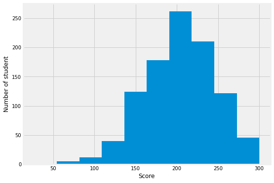

```python
# A histogram to see the score with the highest range (numbers)

plt.figure(figsize=(8, 6))
plt.hist(student_data.total_score)
plt.xlabel('Score')
plt.ylabel('Number of student')
plt.show()
```

### Many student seems to have scored between 180 and 210.

## How many students scored A, B, C, D or F?

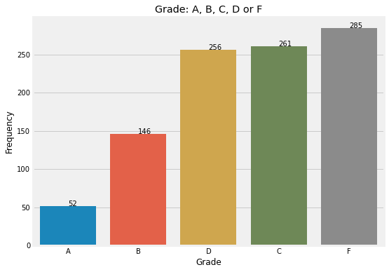

```
A     52
B    146
D    256
C    261
F    285
Name: grade, dtype: int64
```

```python
# Grades are plotted in ascending order

plt.figure(figsize=(8, 6))
values = student_data['grade'].value_counts(ascending=True).values
# colors = ['#0101DF', "#DF0101"]
plt.title('Grade: A, B, C, D or F')
ax = sb.countplot(x='grade', data=student_data, order=student_data['grade'].value_counts(ascending=True).index)
for x, y in enumerate(ax.patches):
    height = y.get_height()
    ax.text(y.get_x()+y.get_width()/2., height + .1, values[x])
plt.xlabel('Grade')
plt.ylabel('Frequency')
plt.show()
print(student_data['grade'].value_counts(ascending=True))
```

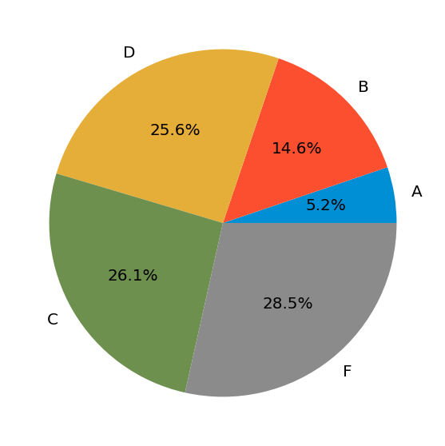

```
A     52
B    146
D    256
C    261
F    285
Name: grade, dtype: int64
```

```python
# To chow the percentage of students in each grade, a pie chat is used

category_names = ['A', 'B', 'D', 'C', 'F']
sizes = [student_data['grade'].value_counts(ascending=True)[0],
         student_data['grade'].value_counts(ascending=True)[1],
         student_data['grade'].value_counts(ascending=True)[2],
         student_data['grade'].value_counts(ascending=True)[3],
         student_data['grade'].value_counts(ascending=True)[4]]

plt.figure(figsize=(10,10))
plt.pie(sizes, labels=category_names, autopct='%1.1f%%', textprops={'fontsize': 20})
plt.show()
print(student_data['grade'].value_counts(ascending=True))
```

### Discuss the distribution(s) of your variable(s) of interest. Were there any unusual points? Did you need to perform any transformations?

> My variables of interest were categorical and numerical. And ther weren't any transformation to the data except for the two new columns created: total_score and grade.

### Of the features you investigated, were there any unusual distributions? Did you perform any operations on the data to tidy, adjust, or change the form of the data? If so, why did you do this?

> My data came in clean and hence no much cleaning was needed. For the two columns created, total_score was gotten by adding math score, reading score and writing score, and grade which was gotten by dividing total_score by 300 and multiplying by 100 and then assigning grades accordingly.

## Bivariate Exploration

> Now lets see the factor(s) that affected or contributed to this scores/grades.

```python
student_data.head()
```

|  | gender | race/ethnicity | parental level of education | lunch | test preparation course | math score | reading score | writing score | total_score | grade |
| --- | --- | --- | --- | --- | --- | --- | --- | --- | --- | --- |
| 0 | female | group B | bachelor's degree | standard | none | 72 | 72 | 74 | 218 | C |
| 1 | female | group C | some college | standard | completed | 69 | 90 | 88 | 247 | B |
| 2 | female | group B | master's degree | standard | none | 90 | 95 | 93 | 278 | A |
| 3 | male | group A | associate's degree | free/reduced | none | 47 | 57 | 44 | 148 | F |
| 4 | male | group C | some college | standard | none | 76 | 78 | 75 | 229 | C |

```python
student_data.tail()
```

|  | gender | race/ethnicity | parental level of education | lunch | test preparation course | math score | reading score | writing score | total_score | grade |
| --- | --- | --- | --- | --- | --- | --- | --- | --- | --- | --- |
| 995 | female | group E | master's degree | standard | completed | 88 | 99 | 95 | 282 | A |
| 996 | male | group C | high school | free/reduced | none | 62 | 55 | 55 | 172 | F |
| 997 | female | group C | high school | free/reduced | completed | 59 | 71 | 65 | 195 | D |
| 998 | female | group D | some college | standard | completed | 68 | 78 | 77 | 223 | C |
| 999 | female | group D | some college | free/reduced | none | 77 | 86 | 86 | 249 | B |

## What is the relationship between gender and grade?

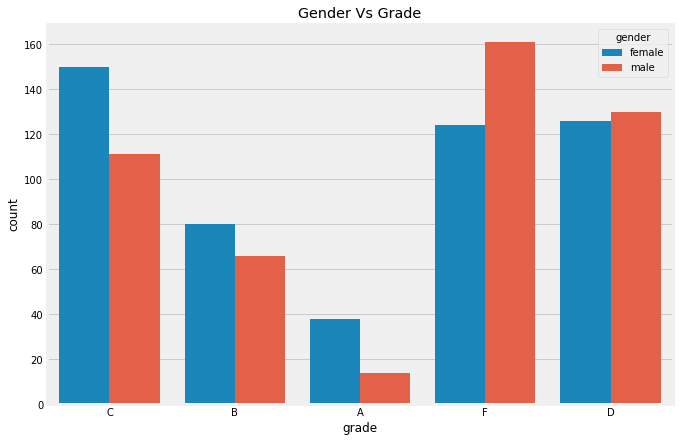

```python
plt.figure(figsize=(10, 7))
plt.title('Gender vs grade'.title())
sb.countplot(x='grade', hue='gender', data=student_data)
plt.show()
```

### From our observation ealier, more females than males took the test. Now looking at the plot, it seems the females did better than the males in this test, because from the count, about 40 females got A while less than 20 males got A. Again over 160 males got F while about 122 females got F. this same trend is seen in the other grades as well.

### I think this could also be as a result of the fact that the ratioof females who took the test was more.

## Does belonging to a perticular race/ethnicity affect or contribute to grade?

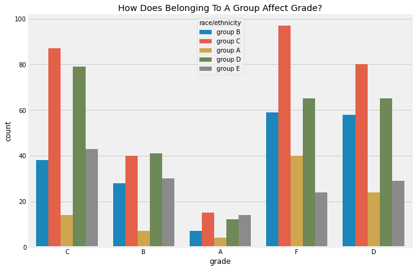

```python
plt.figure(figsize=(10, 7))
plt.title('How does belonging to a group affect grade?'.title())
sb.countplot(x='grade', hue='race/ethnicity', data=student_data)
plt.show()
```

### A lot can be gotten from this plot. Students from Group B seems to be around average in all grades, while those of group C seems to get high pass and high fail too (looking at grade A and F). I think Group E did better in terms of grade because they got many A's, B's and lesser F's and D's.

## How does the parental level of education affect a student's grade?

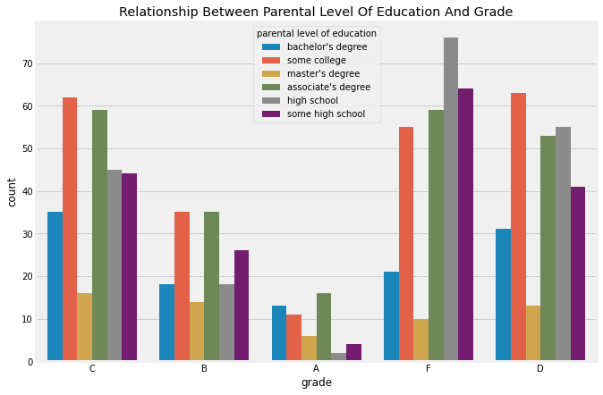

```python
plt.figure(figsize=(10, 7))
plt.title('Relationship between parental level of education and grade'.title())
sb.countplot(x='grade', hue='parental level of education', data=student_data)
plt.show()
```

### It is very clear that students whose parents completed just high school did very poor in the test, they got more F's and less than 10 A's. And students whose parents are masters holders did better.

## Does Lunch affect grade?

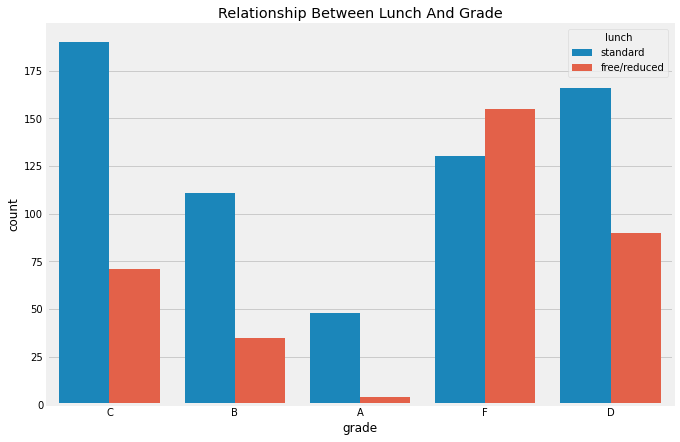

```python
plt.figure(figsize=(10, 7))
plt.title('Relationship between Lunch and grade'.title())
sb.countplot(x='grade', hue='lunch', data=student_data)
plt.show()
```

### Students with standard lunch did quite better than those with free/reduced lunch. With less than 10 students who took free/reduced lunch getting an A while about 50 with standard lunch got an A. Also over 150 student with free/reduced lunch got an F.

## Does taking the test preparation course contribute to grade?

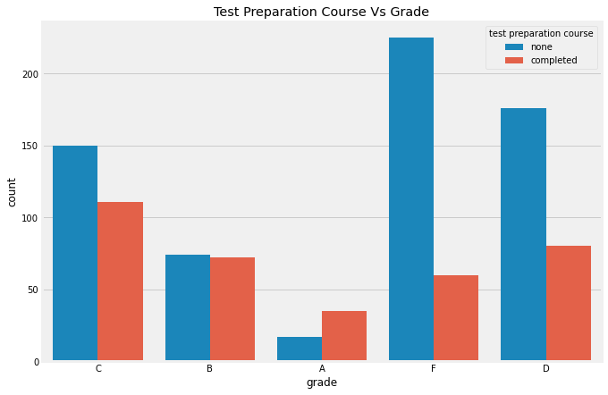

```python
plt.figure(figsize=(10, 7))
plt.title('Test preparation course Vs grade'.title())
sb.countplot(x='grade', hue='test preparation course', data=student_data)
plt.show()
```

## Does Parental level of education depend of race/ethnicity?

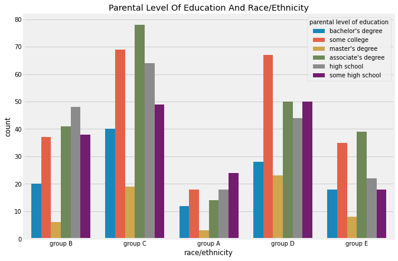

```python
# to see how this relationship we need to use count plot to group this data

plt.figure(figsize=(10, 7))
plt.title('Parental level of education and race/ethnicity'.title())
sb.countplot(x='race/ethnicity', hue='parental level of education', data=student_data)
plt.show()
```

## Does math score affect or contribute to total score?

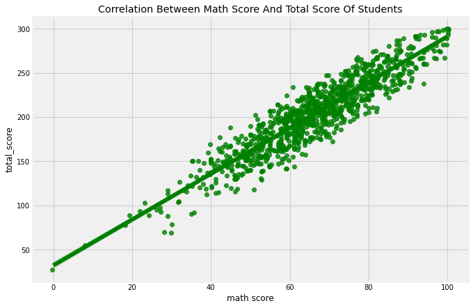

```python
# Ploting to see any correlation between math score and their total score

plt.figure(figsize=(10, 7))
plt.title('Correlation between math score and total score of students'.title())
sb.regplot(x='math score', y='total_score', data=student_data, color='g', x_jitter=.3, y_jitter=.3)
plt.show()
```

### There is a strong positive correlation between math score and total score.

### Talk about some of the relationships you observed in this part of the investigation. How did the feature(s) of interest vary with other features in the dataset?

> Based on features of interest (gender, parental level of education and test preparation course), there were many relationships observed during my analysis. For example, students whose parents are masters holders scored higher than the rest and students who completed the test preparation course got more A's. Also I found that more females took the test and did a little better than the males.

### Did you observe any interesting relationships between the other features (not the main feature(s) of interest)?

> I discovered a lot of relationship between other features like lunch and race/ethnicity as they also contributed or affected how well a student did in their test score/grade. For example those who had standard lunch did quite better than those with free/reduced lunch.

## Multivariate Exploration

> Here we will investigate/look at more relationships between variables.

```python
student_data.head()
```

|  | gender | race/ethnicity | parental level of education | lunch | test preparation course | math score | reading score | writing score | total_score | grade |
| --- | --- | --- | --- | --- | --- | --- | --- | --- | --- | --- |
| 0 | female | group B | bachelor's degree | standard | none | 72 | 72 | 74 | 218 | C |
| 1 | female | group C | some college | standard | completed | 69 | 90 | 88 | 247 | B |
| 2 | female | group B | master's degree | standard | none | 90 | 95 | 93 | 278 | A |
| 3 | male | group A | associate's degree | free/reduced | none | 47 | 57 | 44 | 148 | F |
| 4 | male | group C | some college | standard | none | 76 | 78 | 75 | 229 | C |

## What relationship/correlation exists between math score, reading score, writing score and total score?

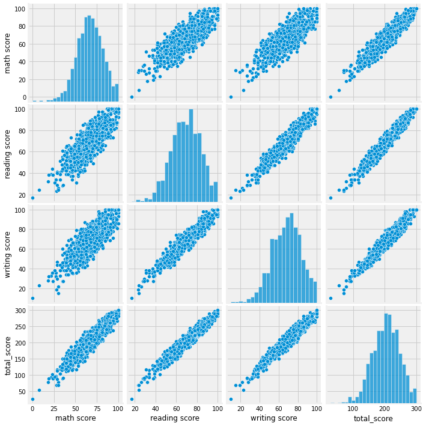

```python
# getting a plot of all variables using seaborns pareplot

sb.pairplot(student_data, )
plt.show()
```

### There is a strong positive correlation between all the numeric features of the student data.

### Talk about some of the relationships you observed in this part of the investigation. Were there features that strengthened each other in terms of looking at your feature(s) of interest?

> Students with high math score seems to do better in other subjects too.

### Were there any interesting or surprising interactions between features?

> There is a strong positive correlation between all the numeric features of the student data

## Conclusions

> The aim of this analysis was to clearly understand how this features relate and how one affects the other. I also created two new columns total_score and grade so as to carry futher analysis as to which features contibutes or affects the grade of a students. It is seen that variables such as a parent level of education can affect a students score/grade in their test.  
> Also another huge factor is the test preparation course, students who completed it seems to do better in their overall score/grade. Other factors such as lunch, race/ethnicity also contibutes as well.